# Chapter 9 ARIMA Models

```r
library(fpp3)
```

ARIMA models provide another approach to time series forecasting. Exponential smoothing and ARIMA models are the two most widely used approaches to time series forecasting, and provide complementary approaches to the problem. While exponential smoothing models are based on a description of the trend and seasonality in the data, ARIMA models aim to describe the **autocorrelations** in the data.

Before we introduce ARIMA models, we must first discuss the concept of **stationarity** and the technique of **differencing** time series.

# 9.1 Starionarity and differencing

A **stationary time series** is one whose statistical properties do not depend on the time at which the series is observed.16 Thus, time series with trends, or with seasonality, are not stationary — the trend and seasonality will affect the value of the time series at different times. On the other hand, a white noise series is stationary — it does not matter when you observe it, it should look much the same at any point in time.

Some cases can be confusing — a time series with cyclic behaviour (but with no trend or seasonality) is stationary. This is because the cycles are not of a fixed length, so before we observe the series we cannot be sure where the peaks and troughs of the cycles will be.

In general, a stationary time series will have no predictable patterns in the long-term. Time plots will show the series to be roughly horizontal (although some cyclic behaviour is possible), with constant variance.

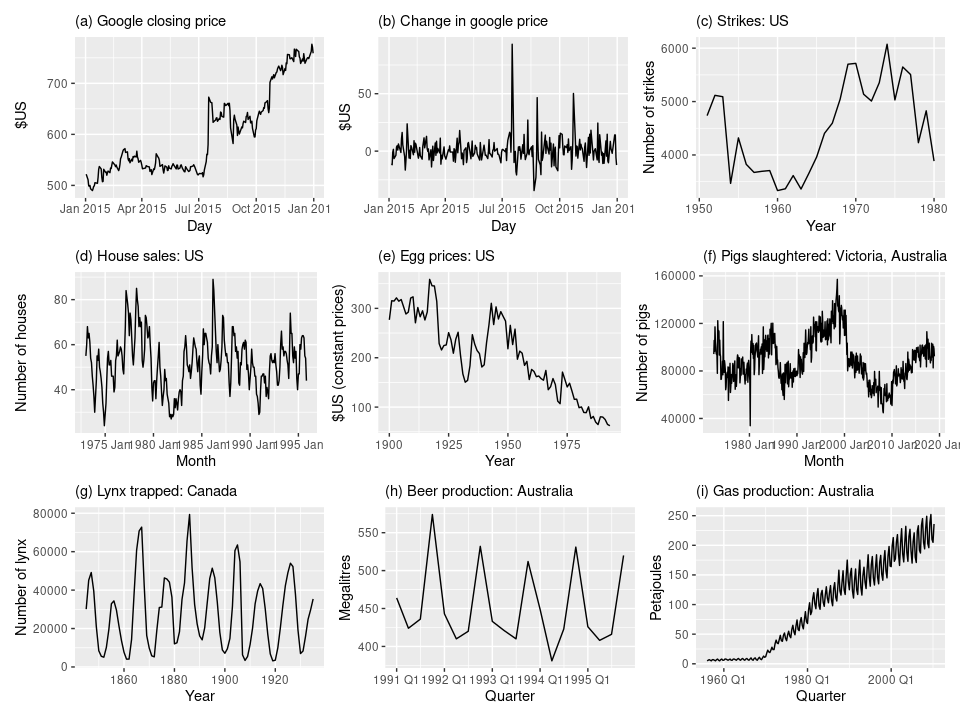

Consider the nine series plotted in Figure 9.1. Which of these do you think are stationary?

Obvious seasonality rules out series (d), (h) and (i). Trends and changing levels rules out series (a), (c), (e), (f) and (i). Increasing variance also rules out (i). That leaves only (b) and (g) as stationary series.

At first glance, the strong cycles in series (g) might appear to make it non-stationary. But these cycles are aperiodic — they are caused when the lynx population becomes too large for the available feed, so that they stop breeding and the population falls to low numbers, then the regeneration of their food sources allows the population to grow again, and so on. In the long-term, the timing of these cycles is not predictable. Hence the series is stationary.

## Differencing

In Figure 9.1, note that the Google stock price was non-stationary in panel (a), but the daily changes were stationary in panel (b). This shows one way to make a non-stationary time series stationary — compute the differences between consecutive observations. This is known as **differencing**.

Transformations such as logarithms can help to stabilise the variance of a time series. Differencing can help stabilise the mean of a time series by removing changes in the level of a time series, and therefore eliminating (or reducing) trend and seasonality.

As well as the time plot of the data, the ACF plot is also useful for identifying non-stationary time series. For a stationary time series, the ACF will drop to zero relatively quickly, while the ACF of non-stationary data decreases slowly. Also, for non-stationary data, the value of $r_1$ is often large and positive.

```r
google_2015 <- gafa_stock |>
  filter(Symbol == "GOOG", year(Date) == 2015)
google_2015
```

| Symbol | Date | Open | High | Low | Close | Adj_Close | Volume |
| --- | --- | --- | --- | --- | --- | --- | --- |
| GOOG | 2015-01-02 | 526.1147 | 528.3624 | 521.2316 | 521.9377 | 521.9377 | 1447600 |
| GOOG | 2015-01-05 | 520.3962 | 521.4604 | 510.2520 | 511.0576 | 511.0576 | 2059800 |
| GOOG | 2015-01-06 | 512.1815 | 513.3500 | 498.3078 | 499.2128 | 499.2128 | 2899900 |
| GOOG | 2015-01-07 | 504.2252 | 504.4679 | 496.9154 | 498.3575 | 498.3575 | 2065100 |
| GOOG | 2015-01-08 | 495.2645 | 500.7245 | 488.3128 | 499.9289 | 499.9289 | 3353600 |
| GOOG | 2015-01-09 | 501.9975 | 502.1566 | 492.0821 | 493.4545 | 493.4545 | 2069400 |
| GOOG | 2015-01-12 | 492.2312 | 493.2616 | 484.8916 | 489.8543 | 489.8543 | 2322400 |
| GOOG | 2015-01-13 | 496.1099 | 500.2272 | 489.6952 | 493.4644 | 493.4644 | 2370500 |
| GOOG | 2015-01-14 | 491.9428 | 500.4759 | 490.3018 | 498.1288 | 498.1288 | 2235700 |
| GOOG | 2015-01-15 | 502.8030 | 502.9124 | 495.0358 | 499.0437 | 499.0437 | 2715800 |

[output cut: 242 more lines]

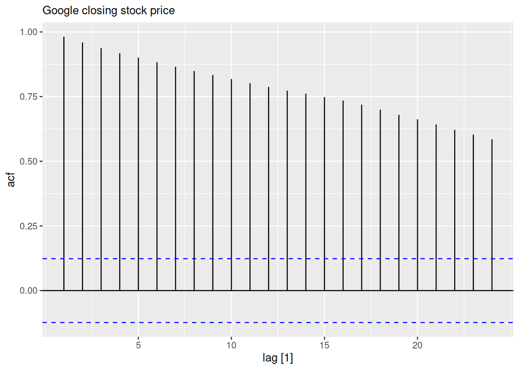

```r
google_2015 |> ACF(Close) |>
  autoplot() + labs(subtitle = "Google closing stock price")
```

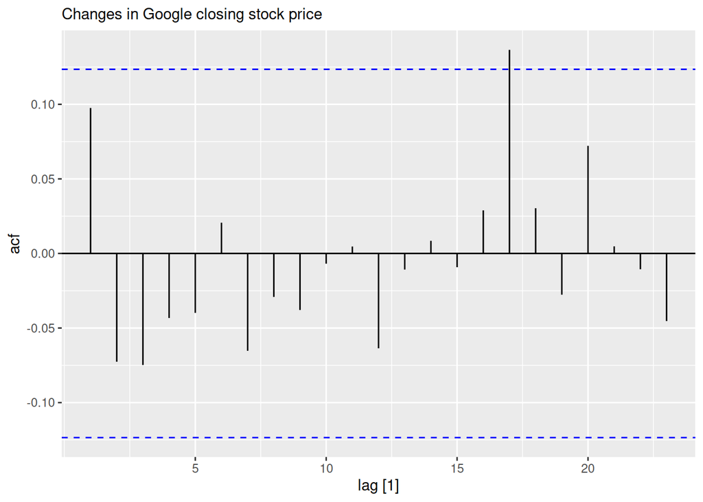

```r
google_2015 |> ACF(difference(Close)) |>
  autoplot() + labs(subtitle = "Changes in Google closing stock price")
```

```r
google_2015 |>
  mutate(diff_close = difference(Close)) |>
  features(diff_close, ljung_box, lag = 10)
```

| Symbol | lb_stat | lb_pvalue |
| --- | --- | --- |
| GOOG | 7.914143 | 0.6372231 |

The ACF of the differenced Google stock price looks just like that of a white noise series. Only one autocorrelation is outside of the 95% limits, and the Ljung-Box $Q^*$ statistic has a p-value of 0.637 (for $h=10$). This suggests that the daily change in the Google stock price is essentially a random amount which is uncorrelated with that of previous days.

## Random walk model

The differenced series is the change between consecutive observations in the original series, and can be written as

$$y'_t = y_t - y_{t-1}.$$

The differenced series will have only $T−1$ values, since it is not possible to calculate a difference $y′1$ for the first observation.

When the differenced series is white noise, the model for the original series can be written as

$$y_t - y_{t-1} =
\varepsilon_t,$$

where $\epsilon_t$ denotes white noise. Rearranging this leads to **the “random walk” model**

$$y_t = y_{t-1} +
\varepsilon_t.$$

Random walk models are widely used for non-stationary data, particularly financial and economic data. Random walks typically have:

- long periods of apparent trends up or down
- sudden and unpredictable changes in direction.

The forecasts from a random walk model are equal to the last observation, as future movements are unpredictable, and are equally likely to be up or down. Thus, the random walk model underpins **naïve forecasts**, first introduced in Section 5.2.

A closely related model allows the differences to have a non-zero mean. Then

$$y_t - y_{t-1} = c +
\varepsilon_t\quad\text{or}\quad {y_t = c + y_{t-1} + \varepsilon_t}\:
.$$

The value of $c$ is the average of the changes between consecutive observations. If $c$ is positive, then the average change is an increase in the value of $y_t$. Thus, $y_t$ will tend to drift upwards. However, if $c$ is negative, $y_t$ will tend to drift downwards.

This is the model behind the **drift method**, also discussed in Section 5.2.

## Second-order differencing

Occasionally the differenced data will not appear to be stationary and it may be necessary to difference the data a second time to obtain a stationary series:

$$\begin{align*}
y''_{t} &= y'_{t} - y'_{t - 1} \\
&= (y_t - y_{t-1}) - (y_{t-1}-y_{t-2})\\
&= y_t - 2y_{t-1} +y_{t-2}.
\end{align*}$$

In this case, $y′′_t$ will have $T−2$ values. Then, we would model the “change in the changes” of the original data. In practice, it is almost never necessary to go beyond second-order differences.

## Seasonal differencing

A seasonal difference is the difference between an observation and the previous observation from the same season. So

$$y'_t = y_t - y_{t-m},$$

where $m=$ the number of seasons. These are also called “lag-$m$ differences”, as we subtract the observation after a lag of $m$ periods.

If seasonally differenced data appear to be white noise, then an appropriate model for the original data is

$$y_t = y_{t-m}+\varepsilon_t.$$

Forecasts from this model are equal to the last observation from the relevant season. That is, this model gives **seasonal naïve forecasts**, introduced in Section 5.2.

The bottom panel in Figure 9.3 shows the seasonal differences of the logarithm of the monthly scripts for A10 (antidiabetic) drugs sold in Australia. The transformation and differencing have made the series look relatively stationary.

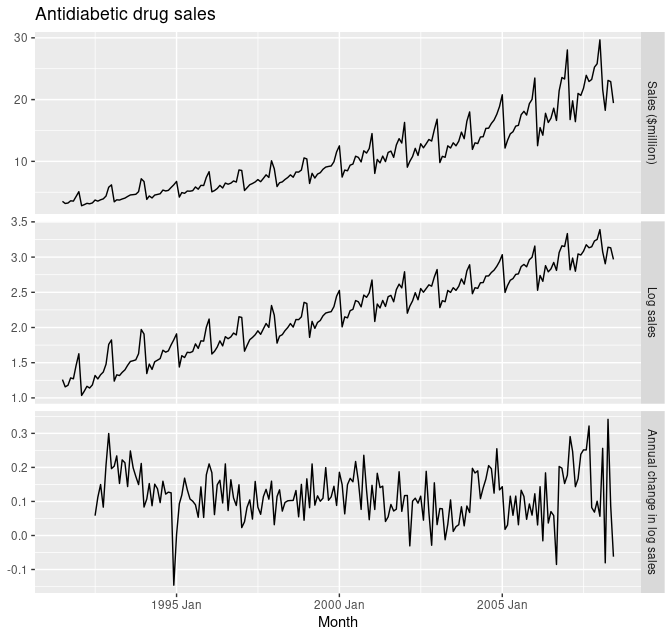

To distinguish seasonal differences from ordinary differences, we sometimes refer to ordinary differences as “first differences”, meaning differences at lag 1.

Sometimes it is necessary to take both a seasonal difference and a first difference to obtain stationary data. Figure 9.4 plots Australian corticosteroid drug sales ($AUD) (top panel). Here, the data are first transformed using logarithms (second panel), then seasonal differences are calculated (third panel). The data still seem somewhat non-stationary, and so a further lot of first differences are computed (bottom panel).

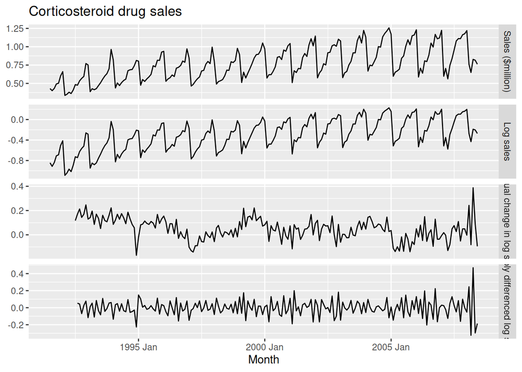

```r
PBS |>
  filter(ATC2 == "H02") |>
  summarise(Cost = sum(Cost)/1e6) |>
  transmute(
    `Sales ($million)` = Cost,
    `Log sales` = log(Cost),
    `Annual change in log sales` = difference(log(Cost),12),
    `Doubly differenced log sales` =
      difference(difference(log(Cost), 12), 1)
  ) |>
  pivot_longer(-Month, names_to = "Type", values_to = "Sales") |>
  mutate(
    Type = factor(Type, levels = c(
      "Sales ($million)",
      "Log sales",
      "Annual change in log sales",
      "Doubly differenced log sales"
    ))
  ) |>
  ggplot(aes(x = Month, y = Sales)) +
  geom_line() +
  facet_grid(vars(Type), scales = "free_y") +
  labs(title = "Corticosteroid drug sales", y = NULL)
```

There is a degree of subjectivity in selecting which differences to apply. The seasonally differenced data in Figure 9.3 do not show substantially different behaviour from the seasonally differenced data in Figure 9.4. In the latter case, we could have decided to stop with the seasonally differenced data, and not done an extra round of differencing. In the former case, we could have decided that the data were not sufficiently stationary and taken an extra round of differencing. Some formal tests for differencing are discussed below, but there are always some choices to be made in the modelling process, and different analysts may make different choices.

If $y′_t=y_t-y_{t−m}$ denotes a seasonally differenced series, then the twice-differenced series is

$$\begin{align*}
y''_t &= y'_t - y'_{t-1} \\
&= (y_t - y_{t-m}) - (y_{t-1} - y_{t-m-1}) \\
&= y_t -y_{t-1} - y_{t-m} + y_{t-m-1}\:
\end{align*}$$

When both seasonal and first differences are applied, it makes no difference which is done first—the result will be the same. However, if the data have a strong seasonal pattern, we recommend that seasonal differencing be done first, because the resulting series will sometimes be stationary and there will be no need for a further first difference. If first differencing is done first, there will still be seasonality present.

Beware that applying more differences than required will induce false dynamics or autocorrelations that do not really exist in the time series. Therefore, do as few differences as necessary to obtain a stationary series.

It is important that if differencing is used, the differences are interpretable. First differences are the change between one observation and the next. Seasonal differences are the change between one year to the next. Other lags are unlikely to make much interpretable sense and should be avoided.

## Unit root tests

One way to determine more objectively whether differencing is required is to use a unit root test. These are statistical hypothesis tests of stationarity that are designed for determining whether differencing is required.

A number of unit root tests are available, which are based on different assumptions and may lead to conflicting answers. In our analysis, we use the Kwiatkowski-Phillips-Schmidt-Shin (KPSS) test (Kwiatkowski et al., 1992). In this test, the null hypothesis is that the data are stationary, and we look for evidence that the null hypothesis is false. Consequently, small p-values (e.g., less than 0.05) suggest that differencing is required. The test can be computed using the `unitroot_kpss()` function.

For example, let us apply it to the Google stock price data.

```r
google_2015 |>
  features(Close, unitroot_kpss)
```

| Symbol | kpss_stat | kpss_pvalue |
| --- | --- | --- |
| GOOG | 3.560958 | 0.01 |

The p-value is reported as 0.01 if it is less than 0.01, and as 0.1 if it is greater than 0.1. In this case, the test statistic (3.56) is bigger than the 1% critical value, so the p-value is less than 0.01, indicating that the null hypothesis is rejected. That is, the data are not stationary. We can difference the data, and apply the test again.

```r
google_2015 |>
  mutate(diff_close = difference(Close)) |>
  features(diff_close, unitroot_kpss)
```

| Symbol | kpss_stat | kpss_pvalue |
| --- | --- | --- |
| GOOG | 0.0988669 | 0.1 |

his time, the test statistic is tiny, and well within the range we would expect for stationary data, so the p-value is greater than 0.1. We can conclude that the differenced data appear stationary.

This process of using a sequence of KPSS tests to determine the appropriate number of first differences is carried out using the `unitroot_ndiffs()` feature.

```r
google_2015 |>
  features(Close, unitroot_ndiffs)
```

| Symbol | ndiffs |
| --- | --- |
| GOOG | 1 |

As we saw from the KPSS tests above, one difference is required to make the google_2015 data stationary.

A similar feature for determining whether seasonal differencing is required is `unitroot_nsdiffs()`, which uses the measure of seasonal strength introduced in Section 4.3 to determine the appropriate number of seasonal differences required. No seasonal differences are suggested if $F_S<0.64$, otherwise one seasonal difference is suggested.

We can apply unitroot_nsdiffs() to the monthly total Australian retail turnover.

```r
aus_total_retail <- aus_retail |>
  summarise(Turnover = sum(Turnover))
aus_total_retail |>
  mutate(log_turnover = log(Turnover)) |>
  features(log_turnover, unitroot_nsdiffs)
```

| nsdiffs |
| --- |
| 1 |

```r
aus_total_retail |>
  mutate(log_turnover = difference(log(Turnover), 12)) |>
  features(log_turnover, unitroot_ndiffs)
```

| ndiffs |
| --- |
| 1 |

Because unitroot_nsdiffs() returns 1 (indicating one seasonal difference is required), we apply the unitroot_ndiffs() function to the seasonally differenced data. These functions suggest we should do both a seasonal difference and a first difference.

# 9.2 Backshift notation

The backward shift operator $B$ is a useful notational device when working with time series lags:

$$B y_{t} = y_{t - 1} \: .$$

(Some references use $L$ for “lag” instead of $B$ for “backshift”.) In other words, $B$, operating on $y_t$, has the effect of shifting the data back one period. Two applications of $B$ to $y_t$ shifts the data back two periods:

$$B(By_{t}) = B^{2}y_{t} = y_{t-2}\:
.$$

For monthly data, if we wish to consider “the same month last year,” the notation is $B^{12}y_t=y_{t−12}$.

The backward shift operator is convenient for describing the process of **differencing**. A first difference can be written as

$$y'_{t} = y_{t} - y_{t-1} = y_t - By_{t} = (1 - B)y_{t}\: .$$

So a first difference can be represented by $(1−B)$. Similarly, if second-order differences have to be computed, then:

$$y''_{t} = y_{t} - 2y_{t - 1} + y_{t - 2} = (1-2B+B^2)y_t = (1 -
B)^{2} y_{t}\: .$$

In general, a $d$th-order difference can be written as

$$(1 - B)^{d} y_{t}.$$

Backshift notation is particularly useful when combining differences, as the operator can be treated using ordinary algebraic rules. In particular, terms involving $B$ can be multiplied together.

For example, a seasonal difference followed by a first difference can be written as

$$\begin{align*}
(1-B)(1-B^m)y_t &= (1 - B - B^m + B^{m+1})y_t \\
&= y_t-y_{t-1}-y_{t-m}+y_{t-m-1},
\end{align*}$$

the same result we obtained earlier.

# 9.3 Autoregressive models

In a multiple regression model, introduced in Chapter 7, we forecast the variable of interest using a linear combination of predictors. In an autoregression model, we forecast the variable of interest using **a linear combination of past values of the variable**. The term autoregression indicates that it is a regression of the variable against itself.

Thus, an autoregressive model of order $p$ can be written as

$$y_{t} = c + \phi_{1}y_{t-1} + \phi_{2}y_{t-2} + \dots + \phi_{p}y_{t-p}
+ \varepsilon_{t},$$

where $\epsilon_t$ is white noise. This is like a multiple regression but with lagged values of $y_t$ as predictors. We refer to this as an **AR($p$) model**, an autoregressive model of order $p$.

Autoregressive models are remarkably flexible at handling a wide range of different time series patterns. The two series in Figure 9.5 show series from an AR(1) model and an AR(2) model. Changing the parameters $\phi_1,\dots,\phi_p$ results in different time series patterns. The variance of the error term $\epsilon_t$ will only change the scale of the series, not the patterns.

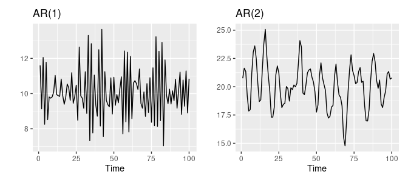

Figure 9.5: Two examples of data from autoregressive models with different parameters. Left: AR(1) with $y_t=18−0.8y_{t−1}+\epsilon_t$. Right: AR(2) with $y_t=8+1.3y_{t−1}−0.7y_{t−2}+\epsilon_t.$ In both cases, $\epsilon_t$ is normally distributed white noise with mean zero and variance one.

or an AR(1) model:

- when $\phi_1=0$ and $c=0$, $y_t$ is equivalent to white noise;
- when $\phi_1=1$ and $c=0$, $y_t$ is equivalent to a random walk;
- when $\phi_1=1$ and $c≠0$, $y_t$ is equivalent to a random walk with drift;
- when $\phi_1<0$, $y_t$ tends to oscillate around the mean.

We normally restrict autoregressive models to stationary data, in which case some constraints on the values of the parameters are required.